# Risk Factor Analysis

## Outcome Variable

**Outcome Variable:** sstunted

## Predictor Variables

**Intervention Variable:** single

**Adjustment Set:**

unadjusted

## Stratifying Variables

The analysis was stratified on these variable(s):

- agecat
- studyid
- country

## Data Summary

| agecat | studyid | country | single | sstunted | n_cell | n |
| --- | --- | --- | --- | --- | --- | --- |
| Birth | COHORTS | GUATEMALA | 0 | 0 | 712 | 767 |
| Birth | COHORTS | GUATEMALA | 0 | 1 | 7 | 767 |
| Birth | COHORTS | GUATEMALA | 1 | 0 | 46 | 767 |
| Birth | COHORTS | GUATEMALA | 1 | 1 | 2 | 767 |
| Birth | COHORTS | INDIA | 0 | 0 | 4630 | 4778 |
| Birth | COHORTS | INDIA | 0 | 1 | 141 | 4778 |
| Birth | COHORTS | INDIA | 1 | 0 | 7 | 4778 |
| Birth | COHORTS | INDIA | 1 | 1 | 0 | 4778 |
| Birth | COHORTS | PHILIPPINES | 0 | 0 | 2893 | 3010 |
| Birth | COHORTS | PHILIPPINES | 0 | 1 | 43 | 3010 |
| Birth | COHORTS | PHILIPPINES | 1 | 0 | 72 | 3010 |
| Birth | COHORTS | PHILIPPINES | 1 | 1 | 2 | 3010 |
| Birth | JiVitA-4 | BANGLADESH | 0 | 0 | 2581 | 2819 |
| Birth | JiVitA-4 | BANGLADESH | 0 | 1 | 233 | 2819 |
| Birth | JiVitA-4 | BANGLADESH | 1 | 0 | 5 | 2819 |
| Birth | JiVitA-4 | BANGLADESH | 1 | 1 | 0 | 2819 |
| Birth | MAL-ED | BANGLADESH | 0 | 0 | 222 | 231 |
| Birth | MAL-ED | BANGLADESH | 0 | 1 | 9 | 231 |
| Birth | MAL-ED | BANGLADESH | 1 | 0 | 0 | 231 |
| Birth | MAL-ED | BANGLADESH | 1 | 1 | 0 | 231 |
| Birth | MAL-ED | BRAZIL | 0 | 0 | 55 | 65 |
| Birth | MAL-ED | BRAZIL | 0 | 1 | 2 | 65 |
| Birth | MAL-ED | BRAZIL | 1 | 0 | 7 | 65 |
| Birth | MAL-ED | BRAZIL | 1 | 1 | 1 | 65 |
| Birth | MAL-ED | INDIA | 0 | 0 | 45 | 47 |
| Birth | MAL-ED | INDIA | 0 | 1 | 2 | 47 |
| Birth | MAL-ED | INDIA | 1 | 0 | 0 | 47 |
| Birth | MAL-ED | INDIA | 1 | 1 | 0 | 47 |
| Birth | MAL-ED | NEPAL | 0 | 0 | 26 | 27 |
| Birth | MAL-ED | NEPAL | 0 | 1 | 1 | 27 |

[output cut: 138 more lines]

The following strata were considered:

- agecat: 24 months, studyid: COHORTS, country: GUATEMALA
- agecat: 24 months, studyid: COHORTS, country: INDIA
- agecat: 24 months, studyid: COHORTS, country: PHILIPPINES
- agecat: 24 months, studyid: JiVitA-4, country: BANGLADESH
- agecat: 24 months, studyid: MAL-ED, country: BANGLADESH
- agecat: 24 months, studyid: MAL-ED, country: BRAZIL
- agecat: 24 months, studyid: MAL-ED, country: INDIA
- agecat: 24 months, studyid: MAL-ED, country: NEPAL
- agecat: 24 months, studyid: MAL-ED, country: PERU
- agecat: 24 months, studyid: MAL-ED, country: SOUTH AFRICA
- agecat: 24 months, studyid: MAL-ED, country: TANZANIA, UNITED REPUBLIC OF
- agecat: 24 months, studyid: PROBIT, country: BELARUS
- agecat: 24 months, studyid: TanzaniaChild2, country: TANZANIA, UNITED REPUBLIC OF
- agecat: 24 months, studyid: ZVITAMBO, country: ZIMBABWE
- agecat: 6 months, studyid: COHORTS, country: GUATEMALA
- agecat: 6 months, studyid: COHORTS, country: INDIA
- agecat: 6 months, studyid: COHORTS, country: PHILIPPINES
- agecat: 6 months, studyid: Guatemala BSC, country: GUATEMALA
- agecat: 6 months, studyid: JiVitA-4, country: BANGLADESH
- agecat: 6 months, studyid: MAL-ED, country: BANGLADESH
- agecat: 6 months, studyid: MAL-ED, country: BRAZIL
- agecat: 6 months, studyid: MAL-ED, country: INDIA
- agecat: 6 months, studyid: MAL-ED, country: NEPAL
- agecat: 6 months, studyid: MAL-ED, country: PERU
- agecat: 6 months, studyid: MAL-ED, country: SOUTH AFRICA
- agecat: 6 months, studyid: MAL-ED, country: TANZANIA, UNITED REPUBLIC OF
- agecat: 6 months, studyid: PROBIT, country: BELARUS
- agecat: 6 months, studyid: TanzaniaChild2, country: TANZANIA, UNITED REPUBLIC OF
- agecat: 6 months, studyid: ZVITAMBO, country: ZIMBABWE
- agecat: Birth, studyid: COHORTS, country: GUATEMALA
- agecat: Birth, studyid: COHORTS, country: INDIA
- agecat: Birth, studyid: COHORTS, country: PHILIPPINES
- agecat: Birth, studyid: JiVitA-4, country: BANGLADESH
- agecat: Birth, studyid: MAL-ED, country: BANGLADESH
- agecat: Birth, studyid: MAL-ED, country: BRAZIL
- agecat: Birth, studyid: MAL-ED, country: INDIA
- agecat: Birth, studyid: MAL-ED, country: NEPAL
- agecat: Birth, studyid: MAL-ED, country: PERU
- agecat: Birth, studyid: MAL-ED, country: SOUTH AFRICA
- agecat: Birth, studyid: MAL-ED, country: TANZANIA, UNITED REPUBLIC OF
- agecat: Birth, studyid: PROBIT, country: BELARUS
- agecat: Birth, studyid: ZVITAMBO, country: ZIMBABWE

### Dropped Strata

Some strata were dropped due to rare outcomes:

- agecat: Birth, studyid: COHORTS, country: GUATEMALA
- agecat: Birth, studyid: COHORTS, country: INDIA
- agecat: Birth, studyid: COHORTS, country: PHILIPPINES
- agecat: Birth, studyid: JiVitA-4, country: BANGLADESH
- agecat: Birth, studyid: MAL-ED, country: BANGLADESH
- agecat: Birth, studyid: MAL-ED, country: BRAZIL
- agecat: Birth, studyid: MAL-ED, country: INDIA
- agecat: Birth, studyid: MAL-ED, country: NEPAL
- agecat: Birth, studyid: MAL-ED, country: PERU
- agecat: Birth, studyid: MAL-ED, country: SOUTH AFRICA
- agecat: Birth, studyid: MAL-ED, country: TANZANIA, UNITED REPUBLIC OF
- agecat: Birth, studyid: PROBIT, country: BELARUS
- agecat: 6 months, studyid: COHORTS, country: INDIA
- agecat: 6 months, studyid: COHORTS, country: PHILIPPINES
- agecat: 6 months, studyid: JiVitA-4, country: BANGLADESH
- agecat: 6 months, studyid: MAL-ED, country: BANGLADESH
- agecat: 6 months, studyid: MAL-ED, country: BRAZIL
- agecat: 6 months, studyid: MAL-ED, country: INDIA
- agecat: 6 months, studyid: MAL-ED, country: NEPAL
- agecat: 6 months, studyid: MAL-ED, country: PERU
- agecat: 6 months, studyid: MAL-ED, country: SOUTH AFRICA
- agecat: 6 months, studyid: MAL-ED, country: TANZANIA, UNITED REPUBLIC OF
- agecat: 6 months, studyid: TanzaniaChild2, country: TANZANIA, UNITED REPUBLIC OF
- agecat: 24 months, studyid: COHORTS, country: INDIA
- agecat: 24 months, studyid: JiVitA-4, country: BANGLADESH
- agecat: 24 months, studyid: MAL-ED, country: BANGLADESH
- agecat: 24 months, studyid: MAL-ED, country: BRAZIL
- agecat: 24 months, studyid: MAL-ED, country: INDIA
- agecat: 24 months, studyid: MAL-ED, country: NEPAL
- agecat: 24 months, studyid: MAL-ED, country: PERU
- agecat: 24 months, studyid: MAL-ED, country: TANZANIA, UNITED REPUBLIC OF
- agecat: 24 months, studyid: PROBIT, country: BELARUS
- agecat: 24 months, studyid: TanzaniaChild2, country: TANZANIA, UNITED REPUBLIC OF

## Methods Detail

We’re interested in the causal parameters $E[Y_a]$ for all values of $a \in \mathcal{A}$. These parameters represent the mean outcome if, possibly contrary to fact, we intervened to set all units to have $A=a$. Under the randomization and positivity assumptions, these are identified by the statistical parameters $\psi_a=E_W[E_{Y|A,W}(Y|A=a,W)]$. In addition, we’re interested in the mean of $Y$, $E[Y]$ under no intervention (the observed mean). We will estimate these parameters by using SuperLearner to fit the relevant likelihood factors – $E_{Y|A,W}(Y|A=a,W)$ and $p(A=a|W)$, and then updating our likelihood fit using a joint TMLE.

For unadjusted analyses ($W=\{\}$), initial likelihoods were estimated using Lrnr_glm to estimate the simple $E(Y|A)$ and Lrnr_mean to estimate $p(A)$. For adjusted analyses, a small library containing Lrnr_glmnet, Lrnr_xgboost, and Lrnr_mean was used.

Having estimated these parameters, we will then use the delta method to estimate relative risks and attributable risks relative to a prespecified baseline level of $A$.

# Results Detail

## Results Plots

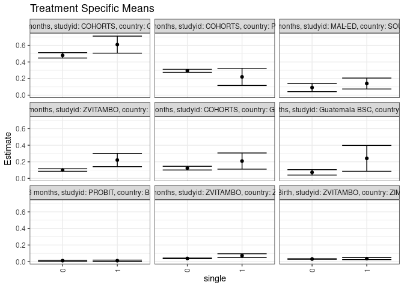

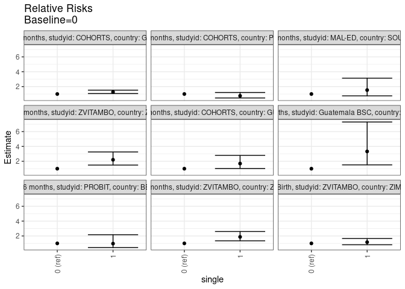

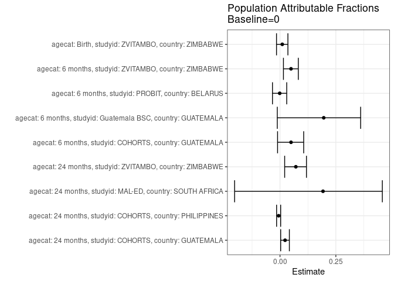

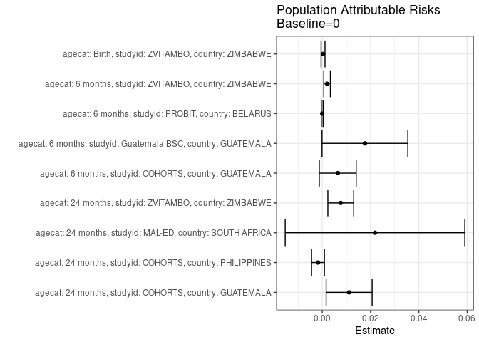

## Results Table

### Parameter: TSM

| agecat | studyid | country | intervention_level | baseline_level | estimate | ci_lower | ci_upper |
| --- | --- | --- | --- | --- | --- | --- | --- |
| Birth | ZVITAMBO | ZIMBABWE | 0 | NA | 0.0314480 | 0.0284411 | 0.0344549 |
| Birth | ZVITAMBO | ZIMBABWE | 1 | NA | 0.0365714 | 0.0241337 | 0.0490091 |
| 6 months | COHORTS | GUATEMALA | 0 | NA | 0.1234867 | 0.1010380 | 0.1459354 |
| 6 months | COHORTS | GUATEMALA | 1 | NA | 0.2089552 | 0.1115502 | 0.3063602 |
| 6 months | Guatemala BSC | GUATEMALA | 0 | NA | 0.0725806 | 0.0402320 | 0.1049293 |
| 6 months | Guatemala BSC | GUATEMALA | 1 | NA | 0.2413793 | 0.0853534 | 0.3974052 |
| 6 months | PROBIT | BELARUS | 0 | NA | 0.0112456 | 0.0052992 | 0.0171921 |
| 6 months | PROBIT | BELARUS | 1 | NA | 0.0108865 | 0.0033545 | 0.0184185 |
| 6 months | ZVITAMBO | ZIMBABWE | 0 | NA | 0.0385231 | 0.0343381 | 0.0427080 |
| 6 months | ZVITAMBO | ZIMBABWE | 1 | NA | 0.0721248 | 0.0497375 | 0.0945120 |
| 24 months | COHORTS | GUATEMALA | 0 | NA | 0.4799567 | 0.4477101 | 0.5122032 |
| 24 months | COHORTS | GUATEMALA | 1 | NA | 0.6091954 | 0.5066156 | 0.7117752 |
| 24 months | COHORTS | PHILIPPINES | 0 | NA | 0.2931693 | 0.2747771 | 0.3115615 |
| 24 months | COHORTS | PHILIPPINES | 1 | NA | 0.2203390 | 0.1170092 | 0.3236688 |
| 24 months | MAL-ED | SOUTH AFRICA | 0 | NA | 0.0916031 | 0.0421014 | 0.1411047 |
| 24 months | MAL-ED | SOUTH AFRICA | 1 | NA | 0.1401869 | 0.0742655 | 0.2061083 |
| 24 months | ZVITAMBO | ZIMBABWE | 0 | NA | 0.1004566 | 0.0854041 | 0.1155092 |
| 24 months | ZVITAMBO | ZIMBABWE | 1 | NA | 0.2211538 | 0.1413659 | 0.3009418 |

### Parameter: E(Y)

| agecat | studyid | country | intervention_level | baseline_level | estimate | ci_lower | ci_upper |
| --- | --- | --- | --- | --- | --- | --- | --- |
| Birth | ZVITAMBO | ZIMBABWE | NA | NA | 0.0317725 | 0.0288478 | 0.0346971 |
| 6 months | COHORTS | GUATEMALA | NA | NA | 0.1298992 | 0.1078368 | 0.1519617 |
| 6 months | Guatemala BSC | GUATEMALA | NA | NA | 0.0902527 | 0.0564475 | 0.1240580 |
| 6 months | PROBIT | BELARUS | NA | NA | 0.0112310 | 0.0054733 | 0.0169886 |
| 6 months | ZVITAMBO | ZIMBABWE | NA | NA | 0.0405186 | 0.0363604 | 0.0446769 |
| 24 months | COHORTS | GUATEMALA | NA | NA | 0.4910891 | 0.4602428 | 0.5219354 |
| 24 months | COHORTS | PHILIPPINES | NA | NA | 0.2913907 | 0.2732677 | 0.3095138 |
| 24 months | MAL-ED | SOUTH AFRICA | NA | NA | 0.1134454 | 0.0730697 | 0.1538211 |
| 24 months | ZVITAMBO | ZIMBABWE | NA | NA | 0.1081246 | 0.0930769 | 0.1231723 |

### Parameter: RR

| agecat | studyid | country | intervention_level | baseline_level | estimate | ci_lower | ci_upper |
| --- | --- | --- | --- | --- | --- | --- | --- |
| Birth | ZVITAMBO | ZIMBABWE | 0 | 0 | 1.0000000 | 1.0000000 | 1.000000 |
| Birth | ZVITAMBO | ZIMBABWE | 1 | 0 | 1.1629175 | 0.8168114 | 1.655679 |
| 6 months | COHORTS | GUATEMALA | 0 | 0 | 1.0000000 | 1.0000000 | 1.000000 |
| 6 months | COHORTS | GUATEMALA | 1 | 0 | 1.6921276 | 1.0259726 | 2.790811 |
| 6 months | Guatemala BSC | GUATEMALA | 0 | 0 | 1.0000000 | 1.0000000 | 1.000000 |
| 6 months | Guatemala BSC | GUATEMALA | 1 | 0 | 3.3256705 | 1.5166712 | 7.292342 |
| 6 months | PROBIT | BELARUS | 0 | 0 | 1.0000000 | 1.0000000 | 1.000000 |
| 6 months | PROBIT | BELARUS | 1 | 0 | 0.9680633 | 0.4323138 | 2.167746 |
| 6 months | ZVITAMBO | ZIMBABWE | 0 | 0 | 1.0000000 | 1.0000000 | 1.000000 |
| 6 months | ZVITAMBO | ZIMBABWE | 1 | 0 | 1.8722481 | 1.3475413 | 2.601266 |
| 24 months | COHORTS | GUATEMALA | 0 | 0 | 1.0000000 | 1.0000000 | 1.000000 |
| 24 months | COHORTS | GUATEMALA | 1 | 0 | 1.2692717 | 1.0588132 | 1.521563 |
| 24 months | COHORTS | PHILIPPINES | 0 | 0 | 1.0000000 | 1.0000000 | 1.000000 |
| 24 months | COHORTS | PHILIPPINES | 1 | 0 | 0.7515760 | 0.4682659 | 1.206294 |
| 24 months | MAL-ED | SOUTH AFRICA | 0 | 0 | 1.0000000 | 1.0000000 | 1.000000 |
| 24 months | MAL-ED | SOUTH AFRICA | 1 | 0 | 1.5303738 | 0.7476410 | 3.132578 |
| 24 months | ZVITAMBO | ZIMBABWE | 0 | 0 | 1.0000000 | 1.0000000 | 1.000000 |
| 24 months | ZVITAMBO | ZIMBABWE | 1 | 0 | 2.2014860 | 1.4895487 | 3.253697 |

### Parameter: PAR

| agecat | studyid | country | intervention_level | baseline_level | estimate | ci_lower | ci_upper |
| --- | --- | --- | --- | --- | --- | --- | --- |
| Birth | ZVITAMBO | ZIMBABWE | 0 | NA | 0.0003245 | -0.0004862 | 0.0011351 |
| 6 months | COHORTS | GUATEMALA | 0 | NA | 0.0064125 | -0.0012313 | 0.0140564 |
| 6 months | Guatemala BSC | GUATEMALA | 0 | NA | 0.0176721 | -0.0000894 | 0.0354335 |
| 6 months | PROBIT | BELARUS | 0 | NA | -0.0000147 | -0.0003765 | 0.0003472 |
| 6 months | ZVITAMBO | ZIMBABWE | 0 | NA | 0.0019956 | 0.0006326 | 0.0033585 |
| 24 months | COHORTS | GUATEMALA | 0 | NA | 0.0111324 | 0.0016037 | 0.0206612 |
| 24 months | COHORTS | PHILIPPINES | 0 | NA | -0.0017786 | -0.0044404 | 0.0008833 |
| 24 months | MAL-ED | SOUTH AFRICA | 0 | NA | 0.0218423 | -0.0153477 | 0.0590323 |
| 24 months | ZVITAMBO | ZIMBABWE | 0 | NA | 0.0076680 | 0.0023160 | 0.0130200 |

### Parameter: PAF

| agecat | studyid | country | intervention_level | baseline_level | estimate | ci_lower | ci_upper |
| --- | --- | --- | --- | --- | --- | --- | --- |
| Birth | ZVITAMBO | ZIMBABWE | 0 | NA | 0.0102118 | -0.0156162 | 0.0353831 |
| 6 months | COHORTS | GUATEMALA | 0 | NA | 0.0493655 | -0.0108817 | 0.1060220 |
| 6 months | Guatemala BSC | GUATEMALA | 0 | NA | 0.1958065 | -0.0121457 | 0.3610334 |
| 6 months | PROBIT | BELARUS | 0 | NA | -0.0013047 | -0.0337044 | 0.0300795 |
| 6 months | ZVITAMBO | ZIMBABWE | 0 | NA | 0.0492505 | 0.0153753 | 0.0819602 |
| 24 months | COHORTS | GUATEMALA | 0 | NA | 0.0226689 | 0.0030245 | 0.0419262 |
| 24 months | COHORTS | PHILIPPINES | 0 | NA | -0.0061037 | -0.0152774 | 0.0029872 |
| 24 months | MAL-ED | SOUTH AFRICA | 0 | NA | 0.1925360 | -0.2032610 | 0.4581408 |
| 24 months | ZVITAMBO | ZIMBABWE | 0 | NA | 0.0709181 | 0.0208870 | 0.1183928 |